# DAPC analysis

Discriminant analysis of principal comonents will give us some more insights into possible clustering within the population.  
We would like to se eif there are effects of our treatments, variety and fungicide programmes.  
Another interesting thing to look at is year to year variation of the pathogen population structure.

## Load packages

```r
list.of.packages <-
  c(
    "tidyverse",
    "devtools",
    "here",
    "readxl",
    "poppr",
    "egg",
    "parallel",
    "conflicted"
  )

new.packages <-
  list.of.packages[!(list.of.packages %in% installed.packages()[, "Package"])]

#Download packages that are not already present in the library
if (length(new.packages))
  install.packages(new.packages)

packages_load <-
  lapply(list.of.packages, require, character.only = TRUE)

#Print warning if there is a problem with installing/loading some of packages
if (any(as.numeric(packages_load) == 0)) {
  warning(paste("Package/s: ", paste(list.of.packages[packages_load != TRUE], sep = ", "), "not loaded!"))
} else {
  print("All packages were successfully loaded.")
}
```

```
## [1] "All packages were successfully loaded."
```

```r
rm(list.of.packages, new.packages, packages_load)

#if instal is not working try
#install.packages("package_name", repos = c(CRAN="https://cran.r-project.org/"))
```

## Data import/preparation

```r
path <- here::here("data", "gen data", "final", "pop.csv")

monpop <- read.genalex(path, ploidy = 3)

splitStrata(monpop) <- ~variety/genotype/year

monpop
```

```
##
## This is a genclone object
## -------------------------
## Genotype information:
##
##      29 original multilocus genotypes
##    1287 triploid individuals
##      12 codominant loci
##
## Population information:
##
##       3 strata - variety, genotype, year
##      51 populations defined -
## KE_6A1_2016, KE_8A1_2016, SE_6A1_2016, ..., CL_8A1_2019, SM_13A2_2019, SM_6A1_2019
```

## DAPC

Very good tutorials are avaialble at [adegent page](https://github.com/thibautjombart/adegenet/wiki/Tutorials) and [Grünwald lab web page](https://grunwaldlab.github.io/Population_Genetics_in_R/DAPC.html).  
Set paralel processing. This argument should be removed if the code is to be reproduced on machine which can not devote muliple cores, although that is probably not a good idea.  
We will also assign a number of cores to be used. We will set it to be one less than the maximum no. of cores, so we dont ‘sufficate’ the computer.

```r
#Determine the OS to assign apropriate character string for parallel processing
 parallel_proc <-
  ifelse(Sys.info()['sysname'] == "Windows", "snow", "multicore")

cpus <-  ifelse(detectCores()>1, c(detectCores()-1), 1)
cpus
```

```
## [1] 3
```

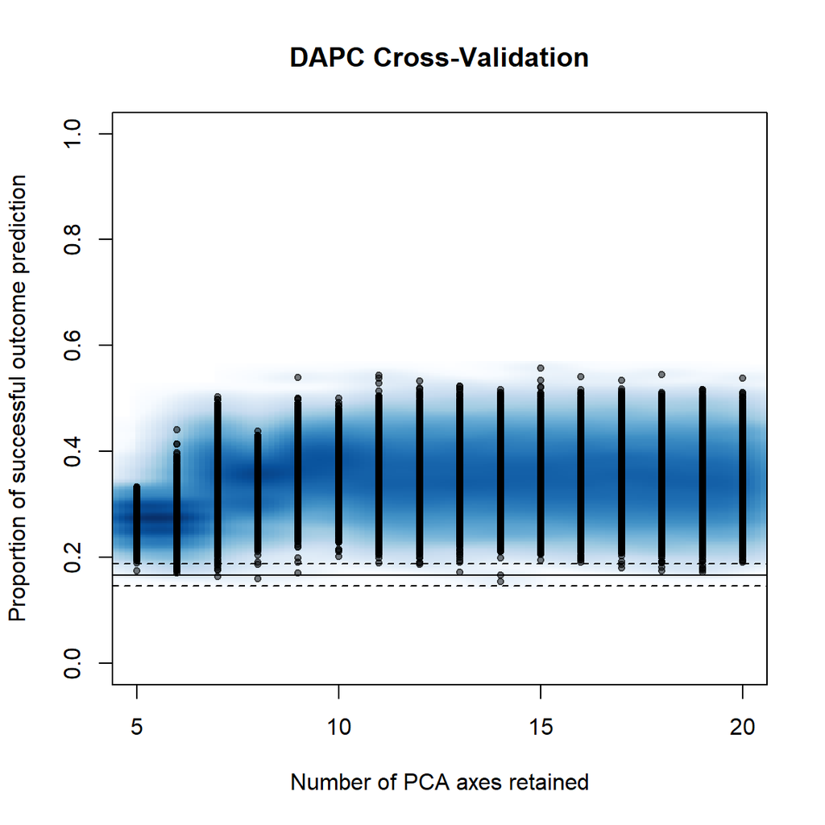

```
##    user  system elapsed
##    2.70   11.48 2116.67
```

```r
setPop(monpop) <- ~variety


set.seed(999)
system.time(pramx_var <- xvalDapc(tab(monpop, NA.method = "mean"), pop(monpop),
                              n.pca = 5:20, n.rep = 3000,
                              parallel = parallel_proc,
                              ncpus = cpus))
```

```r
pramx_var$DAPC$grp <-
  factor(pramx_var$DAPC$grp, levels = c("KE", "BQ", "RO", "SE", "CL", "SM"))

saveRDS(pramx_var, file = here::here("results", "gen","dapc",  "dapc_var.RDS"))

pramx_var[-1]
```

```
## $`Median and Confidence Interval for Random Chance`
##      2.5%       50%     97.5%
## 0.1467338 0.1661992 0.1886241
##
## $`Mean Successful Assignment by Number of PCs of PCA`
##         5         6         7         8         9        10        11
## 0.2730540 0.2728561 0.3552892 0.3334346 0.3704557 0.3690657 0.3538678
##        12        13        14        15        16        17        18
## 0.3531531 0.3555095 0.3550308 0.3530775 0.3528859 0.3502401 0.3470336
##        19        20
## 0.3477586 0.3451197
##
## $`Number of PCs Achieving Highest Mean Success`
## [1] "9"
##
## $`Root Mean Squared Error by Number of PCs of PCA`
##         5         6         7         8         9        10        11
## 0.7274632 0.7279596 0.6469221 0.6677518 0.6311896 0.6326754 0.6485469
##        12        13        14        15        16        17        18
## 0.6493268 0.6468479 0.6474039 0.6493336 0.6496022 0.6523005 0.6554448
##        19        20
## 0.6548385 0.6572916
##
## $`Number of PCs Achieving Lowest MSE`
## [1] "9"
##
## $DAPC
##  #################################################
##  # Discriminant Analysis of Principal Components #
##  #################################################
## class: dapc
## $call: dapc.data.frame(x = as.data.frame(x), grp = ..1, n.pca = ..2,
##     n.da = ..3)
##
## $n.pca: 9 first PCs of PCA used
## $n.da: 5 discriminant functions saved
## $var (proportion of conserved variance): 0.988
##
## $eig (eigenvalues): 173.9 25.19 12.21 1.484 0.7428  vector    length content
## 1 $eig      5      eigenvalues
```

[output cut: 10 more lines]

```
## 3 $loadings     9    5
## 4 $ind.coord    1287 5
## 5 $grp.coord    6    5
## 6 $posterior    1287 6
## 7 $pca.loadings 60   9
## 8 $var.contr    60   5
##   content
## 1 retained PCs of PCA
## 2 group means
## 3 loadings of variables
## 4 coordinates of individuals (principal components)
## 5 coordinates of groups
## 6 posterior membership probabilities
## 7 PCA loadings of original variables
## 8 contribution of original variables
```

```r
pramx_var[-1]$`Number of PCs Achieving Highest Mean Success`
```

```
## [1] "9"
```

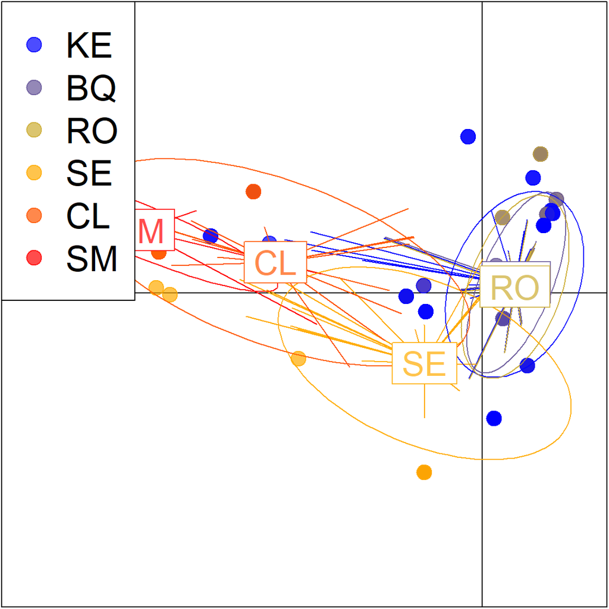

```r
#Reorder levels of the factor for plotting
pramx_var$DAPC$grp <-
factor(pramx_var$DAPC$grp, levels = c("KE", "BQ", "RO", "SE", "CL", "SM"))


scatter(
  pramx_var$DAPC,
  legend = TRUE,
  cex = 3,
  # pch=18:23,
  posi.leg = "topleft",
  scree.da = FALSE,
  clab =2,
  cleg = 2.1,
  cell = 1, #zoom
  xax = 1,
  yax = 2,
  inset.solid = 1,
  cstar=0.5,
  lwd=.1
)
```

## Treatment effect

Prepare the data in genalex format once again. We can define only thre stratums, so we will prepare another file which will be re-used for same purpose as above.

```r
fin <-  readRDS(file = here::here("data", "gen data", "final", "gendata.rds") )

fin <-
  unite(fin, "Ind", idd, year, remove = F)

fin <-
  unite(fin, "Pop", treatment, Genotype, year)


 popcol <- match("Pop",names(fin))
 idcol <- match("Ind",names(fin))


gen <-
fin[ , c(idcol,popcol,match("D13",names(fin)):match("X__24",names(fin)))]


path <- here::here("data", "gen data", "final", "pop2.csv")

data.frame(ssr = c(12,"PInf_Ireland"),
           samples = nrow(gen),
           pop =  length(unique(fin$Pop)))
```

```
##            ssr samples pop
## 1           12    1287  60
## 2 PInf_Ireland    1287  60
```

```r
write.table(data.frame(ssr = 12, samples = nrow(gen), pop =  length(unique(fin$Pop))),
            path,
            sep=",",  col.names=FALSE, row.names = FALSE)

write.table( "PInf_Ireland",
            path,
            sep = ",", row.names = FALSE,
            col.names = FALSE, append = T)
names(gen)[grep("X__", names(gen))] <- ""

write.table(gen,
            path,
            sep = ",",
            row.names = FALSE,
            col.names = !file.exists("myDF.csv"), append = T)
```

So now we have created another file in genalex format, pop2.csv.

```r
path <- here::here("data", "gen data", "final", "pop2.csv")

monpop <- read.genalex(path, ploidy = 3)

splitStrata(monpop) <- ~treatment/genotype/year

monpop
```

```
##
## This is a genclone object
## -------------------------
## Genotype information:
##
##      29 original multilocus genotypes
##    1287 triploid individuals
##      12 codominant loci
##
## Population information:
##
##       3 strata - treatment, genotype, year
##      60 populations defined -
## 0_6A1_2016, 0_8A1_2016, 100_6A1_2016, ..., 100_6A1_2019, IR_6A1_2019, 50_6A1_2019
```

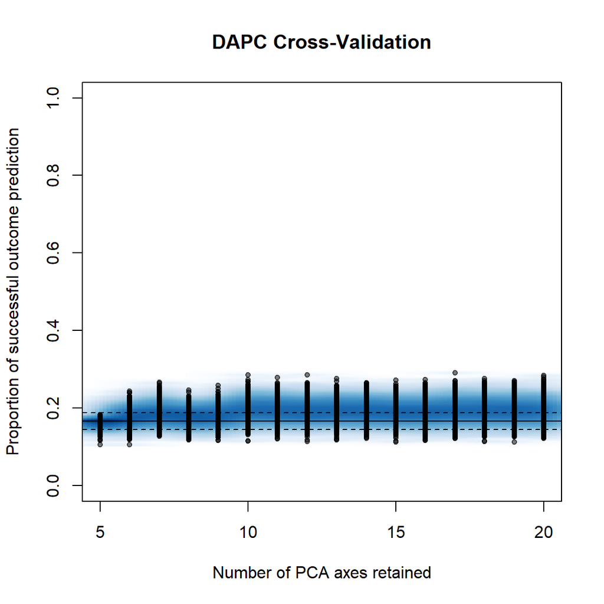

```
##    user  system elapsed
##    1.69    8.30 1179.33
```

```r
setPop(monpop) <- ~treatment

set.seed(999)
system.time(pramx_trt <- xvalDapc(tab(monpop, NA.method = "mean"), pop(monpop),
                              n.pca = 5:20,
                              n.rep = 3000,
                              parallel = parallel_proc,
                              ncpus = cpus))
```

```r
pramx_trt$DAPC$grp <-
  factor(pramx_trt$DAPC$grp, levels = c("0", "100", "50", "IR", "BM", "MIR"))

saveRDS(pramx_trt, file = here::here("results", "gen","dapc",  "dapc_trt.RDS"))

pramx_trt[-1]
```

```
## $`Median and Confidence Interval for Random Chance`
##      2.5%       50%     97.5%
## 0.1451753 0.1667619 0.1879970
##
## $`Mean Successful Assignment by Number of PCs of PCA`
##         5         6         7         8         9        10        11
## 0.1615395 0.1792789 0.1874327 0.1775112 0.1809837 0.1967094 0.1939310
##        12        13        14        15        16        17        18
## 0.1917116 0.1938207 0.1926832 0.1905034 0.1897427 0.1946902 0.1935840
##        19        20
## 0.1932185 0.1919226
##
## $`Number of PCs Achieving Highest Mean Success`
## [1] "10"
##
## $`Root Mean Squared Error by Number of PCs of PCA`
##         5         6         7         8         9        10        11
## 0.8385119 0.8209099 0.8128301 0.8226949 0.8192617 0.8036174 0.8063796
##        12        13        14        15        16        17        18
## 0.8085866 0.8064755 0.8076262 0.8097847 0.8105642 0.8056491 0.8067491
##        19        20
## 0.8071042 0.8084158
##
## $`Number of PCs Achieving Lowest MSE`
## [1] "10"
##
## $DAPC
##  #################################################
##  # Discriminant Analysis of Principal Components #
##  #################################################
## class: dapc
## $call: dapc.data.frame(x = as.data.frame(x), grp = ..1, n.pca = ..2,
##     n.da = ..3)
##
## $n.pca: 10 first PCs of PCA used
## $n.da: 5 discriminant functions saved
## $var (proportion of conserved variance): 0.991
##
## $eig (eigenvalues): 15.81 9.464 3.786 1.946 1.354  vector    length content
## 1 $eig      5      eigenvalues
```

[output cut: 10 more lines]

```
## 3 $loadings     10   5
## 4 $ind.coord    1287 5
## 5 $grp.coord    6    5
## 6 $posterior    1287 6
## 7 $pca.loadings 60   10
## 8 $var.contr    60   5
##   content
## 1 retained PCs of PCA
## 2 group means
## 3 loadings of variables
## 4 coordinates of individuals (principal components)
## 5 coordinates of groups
## 6 posterior membership probabilities
## 7 PCA loadings of original variables
## 8 contribution of original variables
```

```r
scatter(
  pramx_trt$DAPC,
  legend = TRUE,
  cex = 3,
  # pch=18:23,
  posi.leg = "topleft",
  scree.da = FALSE,
  clab =2,
  cleg = 2.1,
  cell = 1, #zoom
  xax = 1,
  yax = 2,
  inset.solid = 1,
  cstar=0.5,
  lwd=.1
)
```

[figure not shown]

## Year effect

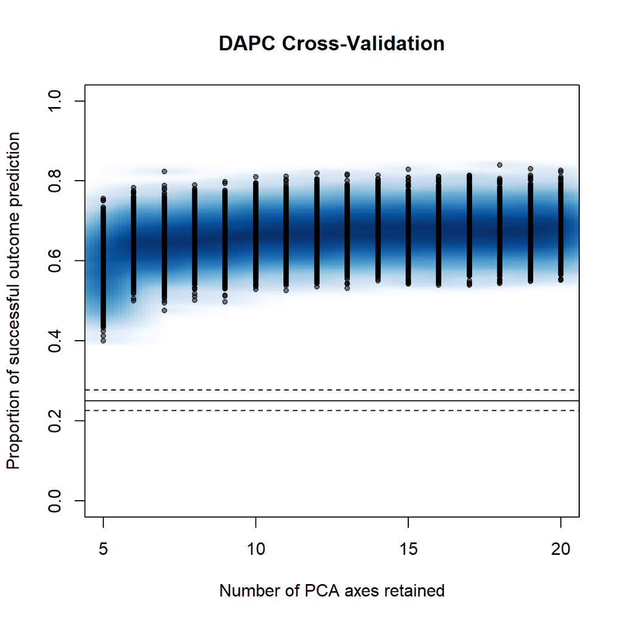

```
##    user  system elapsed
##    1.70    7.30  996.39
```

```r
setPop(monpop) <- ~year

set.seed(999)
system.time(pramx_yr <- xvalDapc(tab(monpop, NA.method = "mean"), pop(monpop),
                              n.pca = 5:20,
                              n.rep = 3000,
                              parallel = parallel_proc,
                              ncpus = cpus))
```

```r
pramx_yr$DAPC$grp <-
  factor(pramx_yr$DAPC$grp, levels = c("2016", "2017", "2018", "2019"))

saveRDS(pramx_yr, file = here::here("results", "gen","dapc",  "dapc_yr.RDS"))

pramx_yr[-1]
```

```
## $`Median and Confidence Interval for Random Chance`
##      2.5%       50%     97.5%
## 0.2257941 0.2507039 0.2773436
##
## $`Mean Successful Assignment by Number of PCs of PCA`
##         5         6         7         8         9        10        11
## 0.5817815 0.6438583 0.6415551 0.6552297 0.6545173 0.6677201 0.6688381
##        12        13        14        15        16        17        18
## 0.6681175 0.6761198 0.6751340 0.6755022 0.6753471 0.6773056 0.6757974
##        19        20
## 0.6776260 0.6795374
##
## $`Number of PCs Achieving Highest Mean Success`
## [1] "20"
##
## $`Root Mean Squared Error by Number of PCs of PCA`
##         5         6         7         8         9        10        11
## 0.4220407 0.3585879 0.3610480 0.3472967 0.3480539 0.3348317 0.3337003
##        12        13        14        15        16        17        18
## 0.3344561 0.3264770 0.3274315 0.3270681 0.3272787 0.3253094 0.3267282
##        19        20
## 0.3250116 0.3230916
##
## $`Number of PCs Achieving Lowest MSE`
## [1] "20"
##
## $DAPC
##  #################################################
##  # Discriminant Analysis of Principal Components #
##  #################################################
## class: dapc
## $call: dapc.data.frame(x = as.data.frame(x), grp = ..1, n.pca = ..2,
##     n.da = ..3)
##
## $n.pca: 20 first PCs of PCA used
## $n.da: 3 discriminant functions saved
## $var (proportion of conserved variance): 1
##
## $eig (eigenvalues): 1249 385.8 251.9  vector    length content
## 1 $eig      3      eigenvalues
```

[output cut: 10 more lines]

```
## 3 $loadings     20   3
## 4 $ind.coord    1287 3
## 5 $grp.coord    4    3
## 6 $posterior    1287 4
## 7 $pca.loadings 60   20
## 8 $var.contr    60   3
##   content
## 1 retained PCs of PCA
## 2 group means
## 3 loadings of variables
## 4 coordinates of individuals (principal components)
## 5 coordinates of groups
## 6 posterior membership probabilities
## 7 PCA loadings of original variables
## 8 contribution of original variables
```

```r
scatter(
  pramx_yr$DAPC,
  legend = TRUE,
  cex = 3,
  # pch=18:23,
  posi.leg = "topleft",
  scree.da = FALSE,
  clab =1.8,
  cleg = 2,
  cell = 1, #zoom
  xax = 1,
  yax = 2,
  inset.solid = 1,
  cstar=0.5,
  lwd=.1
)
```

[figure not shown]